# Risk Factor Analysis

## Outcome Variable

**Outcome Variable:** ever_wasted

## Predictor Variables

**Intervention Variable:** fhtcm

**Adjustment Set:**

- arm
- W_mage
- W_fage
- meducyrs
- feducyrs
- W_mhtcm
- W_mwtkg
- W_mbmi
- single
- delta_W_mage
- delta_W_fage
- delta_meducyrs
- delta_feducyrs
- delta_W_mhtcm
- delta_W_mwtkg
- delta_W_mbmi
- delta_single

## Stratifying Variables

The analysis was stratified on these variable(s):

- agecat
- studyid
- country

## Data Summary

| agecat | studyid | country | fhtcm | ever_wasted | n_cell | n |
| --- | --- | --- | --- | --- | --- | --- |
| 0-24 months | ki1000304b-SAS-CompFeed | INDIA | >=167 cm | 0 | 255 | 895 |
| 0-24 months | ki1000304b-SAS-CompFeed | INDIA | >=167 cm | 1 | 152 | 895 |
| 0-24 months | ki1000304b-SAS-CompFeed | INDIA | <162 cm | 0 | 130 | 895 |
| 0-24 months | ki1000304b-SAS-CompFeed | INDIA | <162 cm | 1 | 96 | 895 |
| 0-24 months | ki1000304b-SAS-CompFeed | INDIA | [162-167) cm | 0 | 145 | 895 |
| 0-24 months | ki1000304b-SAS-CompFeed | INDIA | [162-167) cm | 1 | 117 | 895 |
| 0-24 months | ki1000304b-SAS-FoodSuppl | INDIA | >=167 cm | 0 | 53 | 399 |
| 0-24 months | ki1000304b-SAS-FoodSuppl | INDIA | >=167 cm | 1 | 53 | 399 |
| 0-24 months | ki1000304b-SAS-FoodSuppl | INDIA | <162 cm | 0 | 75 | 399 |
| 0-24 months | ki1000304b-SAS-FoodSuppl | INDIA | <162 cm | 1 | 88 | 399 |
| 0-24 months | ki1000304b-SAS-FoodSuppl | INDIA | [162-167) cm | 0 | 83 | 399 |
| 0-24 months | ki1000304b-SAS-FoodSuppl | INDIA | [162-167) cm | 1 | 47 | 399 |
| 0-24 months | ki1101329-Keneba | GAMBIA | >=167 cm | 0 | 674 | 1933 |
| 0-24 months | ki1101329-Keneba | GAMBIA | >=167 cm | 1 | 574 | 1933 |
| 0-24 months | ki1101329-Keneba | GAMBIA | <162 cm | 0 | 69 | 1933 |
| 0-24 months | ki1101329-Keneba | GAMBIA | <162 cm | 1 | 63 | 1933 |
| 0-24 months | ki1101329-Keneba | GAMBIA | [162-167) cm | 0 | 291 | 1933 |
| 0-24 months | ki1101329-Keneba | GAMBIA | [162-167) cm | 1 | 262 | 1933 |
| 0-24 months | ki1119695-PROBIT | BELARUS | >=167 cm | 0 | 8471 | 12537 |
| 0-24 months | ki1119695-PROBIT | BELARUS | >=167 cm | 1 | 3273 | 12537 |
| 0-24 months | ki1119695-PROBIT | BELARUS | <162 cm | 0 | 121 | 12537 |
| 0-24 months | ki1119695-PROBIT | BELARUS | <162 cm | 1 | 47 | 12537 |
| 0-24 months | ki1119695-PROBIT | BELARUS | [162-167) cm | 0 | 444 | 12537 |
| 0-24 months | ki1119695-PROBIT | BELARUS | [162-167) cm | 1 | 181 | 12537 |
| 0-24 months | ki1135781-COHORTS | GUATEMALA | >=167 cm | 0 | 54 | 495 |
| 0-24 months | ki1135781-COHORTS | GUATEMALA | >=167 cm | 1 | 9 | 495 |
| 0-24 months | ki1135781-COHORTS | GUATEMALA | <162 cm | 0 | 224 | 495 |
| 0-24 months | ki1135781-COHORTS | GUATEMALA | <162 cm | 1 | 69 | 495 |
| 0-24 months | ki1135781-COHORTS | GUATEMALA | [162-167) cm | 0 | 105 | 495 |
| 0-24 months | ki1135781-COHORTS | GUATEMALA | [162-167) cm | 1 | 34 | 495 |

[output cut: 60 more lines]

The following strata were considered:

- agecat: 0-24 months, studyid: ki1000304b-SAS-CompFeed, country: INDIA
- agecat: 0-24 months, studyid: ki1000304b-SAS-FoodSuppl, country: INDIA
- agecat: 0-24 months, studyid: ki1101329-Keneba, country: GAMBIA
- agecat: 0-24 months, studyid: ki1119695-PROBIT, country: BELARUS
- agecat: 0-24 months, studyid: ki1135781-COHORTS, country: GUATEMALA
- agecat: 0-6 months, studyid: ki1000304b-SAS-CompFeed, country: INDIA
- agecat: 0-6 months, studyid: ki1000304b-SAS-FoodSuppl, country: INDIA
- agecat: 0-6 months, studyid: ki1101329-Keneba, country: GAMBIA
- agecat: 0-6 months, studyid: ki1119695-PROBIT, country: BELARUS
- agecat: 0-6 months, studyid: ki1135781-COHORTS, country: GUATEMALA
- agecat: 6-24 months, studyid: ki1000304b-SAS-CompFeed, country: INDIA
- agecat: 6-24 months, studyid: ki1000304b-SAS-FoodSuppl, country: INDIA
- agecat: 6-24 months, studyid: ki1101329-Keneba, country: GAMBIA
- agecat: 6-24 months, studyid: ki1119695-PROBIT, country: BELARUS
- agecat: 6-24 months, studyid: ki1135781-COHORTS, country: GUATEMALA

### Dropped Strata

Some strata were dropped due to rare outcomes:

- agecat: 0-6 months, studyid: ki1135781-COHORTS, country: GUATEMALA
- agecat: 6-24 months, studyid: ki1119695-PROBIT, country: BELARUS

## Methods Detail

We’re interested in the causal parameters $E[Y_a]$ for all values of $a \in \mathcal{A}$. These parameters represent the mean outcome if, possibly contrary to fact, we intervened to set all units to have $A=a$. Under the randomization and positivity assumptions, these are identified by the statistical parameters $\psi_a=E_W[E_{Y|A,W}(Y|A=a,W)]$. In addition, we’re interested in the mean of $Y$, $E[Y]$ under no intervention (the observed mean). We will estimate these parameters by using SuperLearner to fit the relevant likelihood factors – $E_{Y|A,W}(Y|A=a,W)$ and $p(A=a|W)$, and then updating our likelihood fit using a joint TMLE.

For unadjusted analyses ($W=\{\}$), initial likelihoods were estimated using Lrnr_glm to estimate the simple $E(Y|A)$ and Lrnr_mean to estimate $p(A)$. For adjusted analyses, a small library containing Lrnr_glmnet, Lrnr_xgboost, and Lrnr_mean was used.

Having estimated these parameters, we will then use the delta method to estimate relative risks and attributable risks relative to a prespecified baseline level of $A$.

# Results Detail

## Results Plots

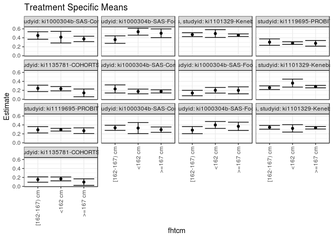

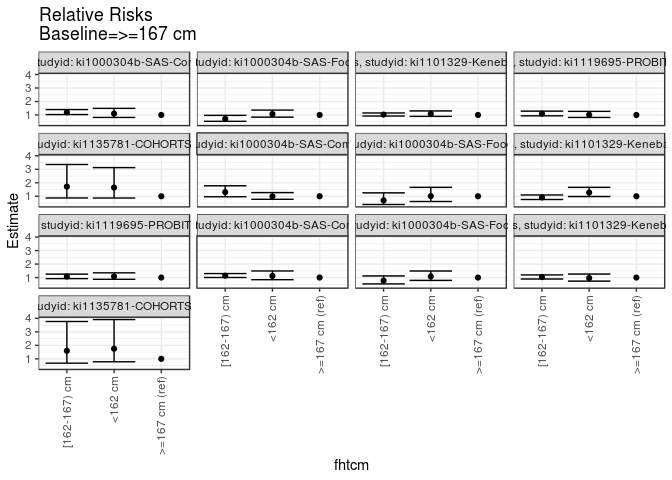

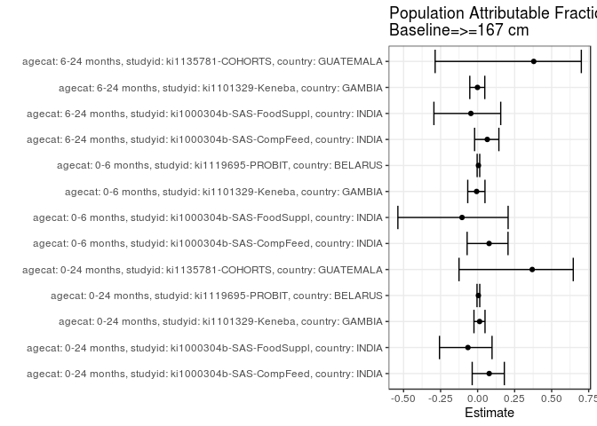

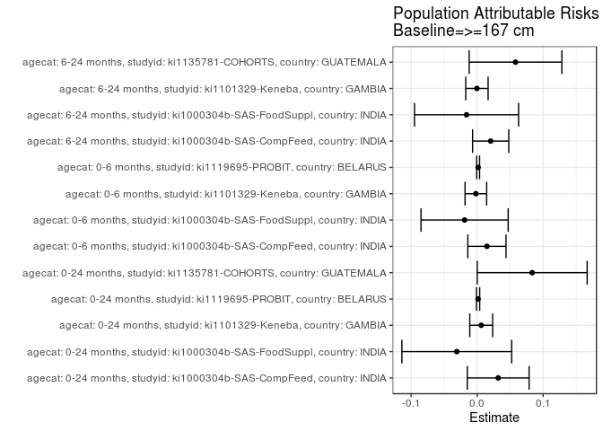

## Results Table

### Parameter: TSM

| agecat | studyid | country | intervention_level | baseline_level | estimate | ci_lower | ci_upper |
| --- | --- | --- | --- | --- | --- | --- | --- |
| 0-24 months | ki1000304b-SAS-CompFeed | INDIA | >=167 cm | NA | 0.3759157 | 0.3159611 | 0.4358703 |
| 0-24 months | ki1000304b-SAS-CompFeed | INDIA | <162 cm | NA | 0.4148985 | 0.2856407 | 0.5441563 |
| 0-24 months | ki1000304b-SAS-CompFeed | INDIA | [162-167) cm | NA | 0.4520849 | 0.3681256 | 0.5360443 |
| 0-24 months | ki1000304b-SAS-FoodSuppl | INDIA | >=167 cm | NA | 0.5019624 | 0.4050018 | 0.5989230 |
| 0-24 months | ki1000304b-SAS-FoodSuppl | INDIA | <162 cm | NA | 0.5368670 | 0.4596994 | 0.6140347 |
| 0-24 months | ki1000304b-SAS-FoodSuppl | INDIA | [162-167) cm | NA | 0.3605605 | 0.2772503 | 0.4438707 |
| 0-24 months | ki1101329-Keneba | GAMBIA | >=167 cm | NA | 0.4588568 | 0.4304650 | 0.4872487 |
| 0-24 months | ki1101329-Keneba | GAMBIA | <162 cm | NA | 0.4956874 | 0.4089984 | 0.5823765 |
| 0-24 months | ki1101329-Keneba | GAMBIA | [162-167) cm | NA | 0.4716901 | 0.4284463 | 0.5149339 |
| 0-24 months | ki1119695-PROBIT | BELARUS | >=167 cm | NA | 0.2777910 | 0.2147236 | 0.3408585 |
| 0-24 months | ki1119695-PROBIT | BELARUS | <162 cm | NA | 0.2831051 | 0.2539275 | 0.3122826 |
| 0-24 months | ki1119695-PROBIT | BELARUS | [162-167) cm | NA | 0.3044429 | 0.2331780 | 0.3757077 |
| 0-24 months | ki1135781-COHORTS | GUATEMALA | >=167 cm | NA | 0.1428571 | 0.0563614 | 0.2293528 |
| 0-24 months | ki1135781-COHORTS | GUATEMALA | <162 cm | NA | 0.2354949 | 0.1868615 | 0.2841282 |
| 0-24 months | ki1135781-COHORTS | GUATEMALA | [162-167) cm | NA | 0.2446043 | 0.1730725 | 0.3161361 |
| 0-6 months | ki1000304b-SAS-CompFeed | INDIA | >=167 cm | NA | 0.1765934 | 0.1410786 | 0.2121081 |
| 0-6 months | ki1000304b-SAS-CompFeed | INDIA | <162 cm | NA | 0.1751496 | 0.1222201 | 0.2280790 |
| 0-6 months | ki1000304b-SAS-CompFeed | INDIA | [162-167) cm | NA | 0.2309799 | 0.1408743 | 0.3210856 |
| 0-6 months | ki1000304b-SAS-FoodSuppl | INDIA | >=167 cm | NA | 0.1994378 | 0.1217242 | 0.2771514 |
| 0-6 months | ki1000304b-SAS-FoodSuppl | INDIA | <162 cm | NA | 0.2013517 | 0.1388697 | 0.2638337 |
| 0-6 months | ki1000304b-SAS-FoodSuppl | INDIA | [162-167) cm | NA | 0.1390567 | 0.0784898 | 0.1996237 |
| 0-6 months | ki1101329-Keneba | GAMBIA | >=167 cm | NA | 0.2830699 | 0.2560132 | 0.3101266 |
| 0-6 months | ki1101329-Keneba | GAMBIA | <162 cm | NA | 0.3612827 | 0.2724968 | 0.4500685 |
| 0-6 months | ki1101329-Keneba | GAMBIA | [162-167) cm | NA | 0.2582845 | 0.2177325 | 0.2988365 |
| 0-6 months | ki1119695-PROBIT | BELARUS | >=167 cm | NA | 0.2705580 | 0.2069174 | 0.3341987 |
| 0-6 months | ki1119695-PROBIT | BELARUS | <162 cm | NA | 0.2931796 | 0.2621170 | 0.3242421 |
| 0-6 months | ki1119695-PROBIT | BELARUS | [162-167) cm | NA | 0.2905785 | 0.2198469 | 0.3613102 |
| 6-24 months | ki1000304b-SAS-CompFeed | INDIA | >=167 cm | NA | 0.2940602 | 0.2345804 | 0.3535399 |
| 6-24 months | ki1000304b-SAS-CompFeed | INDIA | <162 cm | NA | 0.3289792 | 0.2056821 | 0.4522764 |
| 6-24 months | ki1000304b-SAS-CompFeed | INDIA | [162-167) cm | NA | 0.3349952 | 0.2778016 | 0.3921888 |
| 6-24 months | ki1000304b-SAS-FoodSuppl | INDIA | >=167 cm | NA | 0.3680494 | 0.2757477 | 0.4603512 |
| 6-24 months | ki1000304b-SAS-FoodSuppl | INDIA | <162 cm | NA | 0.3984085 | 0.3217199 | 0.4750971 |
| 6-24 months | ki1000304b-SAS-FoodSuppl | INDIA | [162-167) cm | NA | 0.2833837 | 0.2047622 | 0.3620052 |
| 6-24 months | ki1101329-Keneba | GAMBIA | >=167 cm | NA | 0.3352575 | 0.3076645 | 0.3628504 |
| 6-24 months | ki1101329-Keneba | GAMBIA | <162 cm | NA | 0.3222546 | 0.2394769 | 0.4050323 |
| 6-24 months | ki1101329-Keneba | GAMBIA | [162-167) cm | NA | 0.3462821 | 0.3045208 | 0.3880434 |
| 6-24 months | ki1135781-COHORTS | GUATEMALA | >=167 cm | NA | 0.0952381 | 0.0226785 | 0.1677977 |
| 6-24 months | ki1135781-COHORTS | GUATEMALA | <162 cm | NA | 0.1666667 | 0.1235813 | 0.2097521 |
| 6-24 months | ki1135781-COHORTS | GUATEMALA | [162-167) cm | NA | 0.1521739 | 0.0921842 | 0.2121636 |

### Parameter: E(Y)

| agecat | studyid | country | intervention_level | baseline_level | estimate | ci_lower | ci_upper |
| --- | --- | --- | --- | --- | --- | --- | --- |
| 0-24 months | ki1000304b-SAS-CompFeed | INDIA | NA | NA | 0.4078212 | 0.3382171 | 0.4774254 |
| 0-24 months | ki1000304b-SAS-FoodSuppl | INDIA | NA | NA | 0.4711779 | 0.4221376 | 0.5202183 |
| 0-24 months | ki1101329-Keneba | GAMBIA | NA | NA | 0.4650802 | 0.4428393 | 0.4873211 |
| 0-24 months | ki1119695-PROBIT | BELARUS | NA | NA | 0.2792534 | 0.2170833 | 0.3414235 |
| 0-24 months | ki1135781-COHORTS | GUATEMALA | NA | NA | 0.2262626 | 0.1893659 | 0.2631594 |
| 0-6 months | ki1000304b-SAS-CompFeed | INDIA | NA | NA | 0.1914414 | 0.1418556 | 0.2410273 |
| 0-6 months | ki1000304b-SAS-FoodSuppl | INDIA | NA | NA | 0.1804511 | 0.1426701 | 0.2182322 |
| 0-6 months | ki1101329-Keneba | GAMBIA | NA | NA | 0.2811594 | 0.2599381 | 0.3023807 |
| 0-6 months | ki1119695-PROBIT | BELARUS | NA | NA | 0.2720747 | 0.2092007 | 0.3349486 |
| 6-24 months | ki1000304b-SAS-CompFeed | INDIA | NA | NA | 0.3145933 | 0.2482331 | 0.3809535 |
| 6-24 months | ki1000304b-SAS-FoodSuppl | INDIA | NA | NA | 0.3520408 | 0.3047006 | 0.3993810 |
| 6-24 months | ki1101329-Keneba | GAMBIA | NA | NA | 0.3349541 | 0.3134470 | 0.3564611 |
| 6-24 months | ki1135781-COHORTS | GUATEMALA | NA | NA | 0.1533742 | 0.1214029 | 0.1853455 |

### Parameter: RR

| agecat | studyid | country | intervention_level | baseline_level | estimate | ci_lower | ci_upper |
| --- | --- | --- | --- | --- | --- | --- | --- |
| 0-24 months | ki1000304b-SAS-CompFeed | INDIA | >=167 cm | >=167 cm | 1.0000000 | 1.0000000 | 1.0000000 |
| 0-24 months | ki1000304b-SAS-CompFeed | INDIA | <162 cm | >=167 cm | 1.1037008 | 0.8176929 | 1.4897469 |
| 0-24 months | ki1000304b-SAS-CompFeed | INDIA | [162-167) cm | >=167 cm | 1.2026231 | 1.0317274 | 1.4018260 |
| 0-24 months | ki1000304b-SAS-FoodSuppl | INDIA | >=167 cm | >=167 cm | 1.0000000 | 1.0000000 | 1.0000000 |
| 0-24 months | ki1000304b-SAS-FoodSuppl | INDIA | <162 cm | >=167 cm | 1.0695363 | 0.8405339 | 1.3609302 |
| 0-24 months | ki1000304b-SAS-FoodSuppl | INDIA | [162-167) cm | >=167 cm | 0.7183018 | 0.5313784 | 0.9709794 |
| 0-24 months | ki1101329-Keneba | GAMBIA | >=167 cm | >=167 cm | 1.0000000 | 1.0000000 | 1.0000000 |
| 0-24 months | ki1101329-Keneba | GAMBIA | <162 cm | >=167 cm | 1.0802661 | 0.8974648 | 1.3003015 |
| 0-24 months | ki1101329-Keneba | GAMBIA | [162-167) cm | >=167 cm | 1.0279680 | 0.9205775 | 1.1478862 |
| 0-24 months | ki1119695-PROBIT | BELARUS | >=167 cm | >=167 cm | 1.0000000 | 1.0000000 | 1.0000000 |
| 0-24 months | ki1119695-PROBIT | BELARUS | <162 cm | >=167 cm | 1.0191297 | 0.8192260 | 1.2678129 |
| 0-24 months | ki1119695-PROBIT | BELARUS | [162-167) cm | >=167 cm | 1.0959421 | 0.9350007 | 1.2845863 |
| 0-24 months | ki1135781-COHORTS | GUATEMALA | >=167 cm | >=167 cm | 1.0000000 | 1.0000000 | 1.0000000 |
| 0-24 months | ki1135781-COHORTS | GUATEMALA | <162 cm | >=167 cm | 1.6484642 | 0.8694655 | 3.1254076 |
| 0-24 months | ki1135781-COHORTS | GUATEMALA | [162-167) cm | >=167 cm | 1.7122302 | 0.8740675 | 3.3541258 |
| 0-6 months | ki1000304b-SAS-CompFeed | INDIA | >=167 cm | >=167 cm | 1.0000000 | 1.0000000 | 1.0000000 |
| 0-6 months | ki1000304b-SAS-CompFeed | INDIA | <162 cm | >=167 cm | 0.9918241 | 0.7733251 | 1.2720588 |
| 0-6 months | ki1000304b-SAS-CompFeed | INDIA | [162-167) cm | >=167 cm | 1.3079763 | 0.9630636 | 1.7764163 |
| 0-6 months | ki1000304b-SAS-FoodSuppl | INDIA | >=167 cm | >=167 cm | 1.0000000 | 1.0000000 | 1.0000000 |
| 0-6 months | ki1000304b-SAS-FoodSuppl | INDIA | <162 cm | >=167 cm | 1.0095966 | 0.6134320 | 1.6616111 |
| 0-6 months | ki1000304b-SAS-FoodSuppl | INDIA | [162-167) cm | >=167 cm | 0.6972437 | 0.3885364 | 1.2512312 |
| 0-6 months | ki1101329-Keneba | GAMBIA | >=167 cm | >=167 cm | 1.0000000 | 1.0000000 | 1.0000000 |
| 0-6 months | ki1101329-Keneba | GAMBIA | <162 cm | >=167 cm | 1.2763019 | 0.9806053 | 1.6611644 |
| 0-6 months | ki1101329-Keneba | GAMBIA | [162-167) cm | >=167 cm | 0.9124408 | 0.7594273 | 1.0962842 |
| 0-6 months | ki1119695-PROBIT | BELARUS | >=167 cm | >=167 cm | 1.0000000 | 1.0000000 | 1.0000000 |
| 0-6 months | ki1119695-PROBIT | BELARUS | <162 cm | >=167 cm | 1.0836106 | 0.8701474 | 1.3494402 |
| 0-6 months | ki1119695-PROBIT | BELARUS | [162-167) cm | >=167 cm | 1.0739971 | 0.9205981 | 1.2529569 |
| 6-24 months | ki1000304b-SAS-CompFeed | INDIA | >=167 cm | >=167 cm | 1.0000000 | 1.0000000 | 1.0000000 |
| 6-24 months | ki1000304b-SAS-CompFeed | INDIA | <162 cm | >=167 cm | 1.1187480 | 0.8410691 | 1.4881025 |
| 6-24 months | ki1000304b-SAS-CompFeed | INDIA | [162-167) cm | >=167 cm | 1.1392063 | 1.0028645 | 1.2940841 |
| 6-24 months | ki1000304b-SAS-FoodSuppl | INDIA | >=167 cm | >=167 cm | 1.0000000 | 1.0000000 | 1.0000000 |
| 6-24 months | ki1000304b-SAS-FoodSuppl | INDIA | <162 cm | >=167 cm | 1.0824864 | 0.7890812 | 1.4849889 |
| 6-24 months | ki1000304b-SAS-FoodSuppl | INDIA | [162-167) cm | >=167 cm | 0.7699611 | 0.5294473 | 1.1197339 |
| 6-24 months | ki1101329-Keneba | GAMBIA | >=167 cm | >=167 cm | 1.0000000 | 1.0000000 | 1.0000000 |
| 6-24 months | ki1101329-Keneba | GAMBIA | <162 cm | >=167 cm | 0.9612154 | 0.7340175 | 1.2587371 |
| 6-24 months | ki1101329-Keneba | GAMBIA | [162-167) cm | >=167 cm | 1.0328841 | 0.8928748 | 1.1948479 |
| 6-24 months | ki1135781-COHORTS | GUATEMALA | >=167 cm | >=167 cm | 1.0000000 | 1.0000000 | 1.0000000 |
| 6-24 months | ki1135781-COHORTS | GUATEMALA | <162 cm | >=167 cm | 1.7499999 | 0.7827645 | 3.9124152 |
| 6-24 months | ki1135781-COHORTS | GUATEMALA | [162-167) cm | >=167 cm | 1.5978260 | 0.6776121 | 3.7677129 |

### Parameter: PAR

| agecat | studyid | country | intervention_level | baseline_level | estimate | ci_lower | ci_upper |
| --- | --- | --- | --- | --- | --- | --- | --- |
| 0-24 months | ki1000304b-SAS-CompFeed | INDIA | >=167 cm | NA | 0.0319055 | -0.0148847 | 0.0786957 |
| 0-24 months | ki1000304b-SAS-FoodSuppl | INDIA | >=167 cm | NA | -0.0307845 | -0.1139717 | 0.0524027 |
| 0-24 months | ki1101329-Keneba | GAMBIA | >=167 cm | NA | 0.0062234 | -0.0111247 | 0.0235715 |
| 0-24 months | ki1119695-PROBIT | BELARUS | >=167 cm | NA | 0.0014624 | -0.0009773 | 0.0039020 |
| 0-24 months | ki1135781-COHORTS | GUATEMALA | >=167 cm | NA | 0.0834055 | 0.0001079 | 0.1667031 |
| 0-6 months | ki1000304b-SAS-CompFeed | INDIA | >=167 cm | NA | 0.0148481 | -0.0140780 | 0.0437741 |
| 0-6 months | ki1000304b-SAS-FoodSuppl | INDIA | >=167 cm | NA | -0.0189867 | -0.0850276 | 0.0470543 |
| 0-6 months | ki1101329-Keneba | GAMBIA | >=167 cm | NA | -0.0019105 | -0.0182583 | 0.0144373 |
| 0-6 months | ki1119695-PROBIT | BELARUS | >=167 cm | NA | 0.0015166 | -0.0006990 | 0.0037323 |
| 6-24 months | ki1000304b-SAS-CompFeed | INDIA | >=167 cm | NA | 0.0205331 | -0.0068506 | 0.0479168 |
| 6-24 months | ki1000304b-SAS-FoodSuppl | INDIA | >=167 cm | NA | -0.0160086 | -0.0948021 | 0.0627849 |
| 6-24 months | ki1101329-Keneba | GAMBIA | >=167 cm | NA | -0.0003034 | -0.0172524 | 0.0166457 |
| 6-24 months | ki1135781-COHORTS | GUATEMALA | >=167 cm | NA | 0.0581361 | -0.0120811 | 0.1283534 |

### Parameter: PAF

| agecat | studyid | country | intervention_level | baseline_level | estimate | ci_lower | ci_upper |
| --- | --- | --- | --- | --- | --- | --- | --- |
| 0-24 months | ki1000304b-SAS-CompFeed | INDIA | >=167 cm | NA | 0.0782340 | -0.0366587 | 0.1803932 |
| 0-24 months | ki1000304b-SAS-FoodSuppl | INDIA | >=167 cm | NA | -0.0653351 | -0.2574384 | 0.0974199 |
| 0-24 months | ki1101329-Keneba | GAMBIA | >=167 cm | NA | 0.0133813 | -0.0246488 | 0.0499999 |
| 0-24 months | ki1119695-PROBIT | BELARUS | >=167 cm | NA | 0.0052367 | -0.0040163 | 0.0144045 |
| 0-24 months | ki1135781-COHORTS | GUATEMALA | >=167 cm | NA | 0.3686224 | -0.1255915 | 0.6458417 |
| 0-6 months | ki1000304b-SAS-CompFeed | INDIA | >=167 cm | NA | 0.0775593 | -0.0708126 | 0.2053728 |
| 0-6 months | ki1000304b-SAS-FoodSuppl | INDIA | >=167 cm | NA | -0.1052178 | -0.5384517 | 0.2060158 |
| 0-6 months | ki1101329-Keneba | GAMBIA | >=167 cm | NA | -0.0067950 | -0.0666421 | 0.0496942 |
| 0-6 months | ki1119695-PROBIT | BELARUS | >=167 cm | NA | 0.0055743 | -0.0031185 | 0.0141918 |
| 6-24 months | ki1000304b-SAS-CompFeed | INDIA | >=167 cm | NA | 0.0652688 | -0.0202809 | 0.1436453 |
| 6-24 months | ki1000304b-SAS-FoodSuppl | INDIA | >=167 cm | NA | -0.0454737 | -0.2950886 | 0.1560305 |
| 6-24 months | ki1101329-Keneba | GAMBIA | >=167 cm | NA | -0.0009057 | -0.0528068 | 0.0484368 |
| 6-24 months | ki1135781-COHORTS | GUATEMALA | >=167 cm | NA | 0.3790476 | -0.2868794 | 0.7003745 |